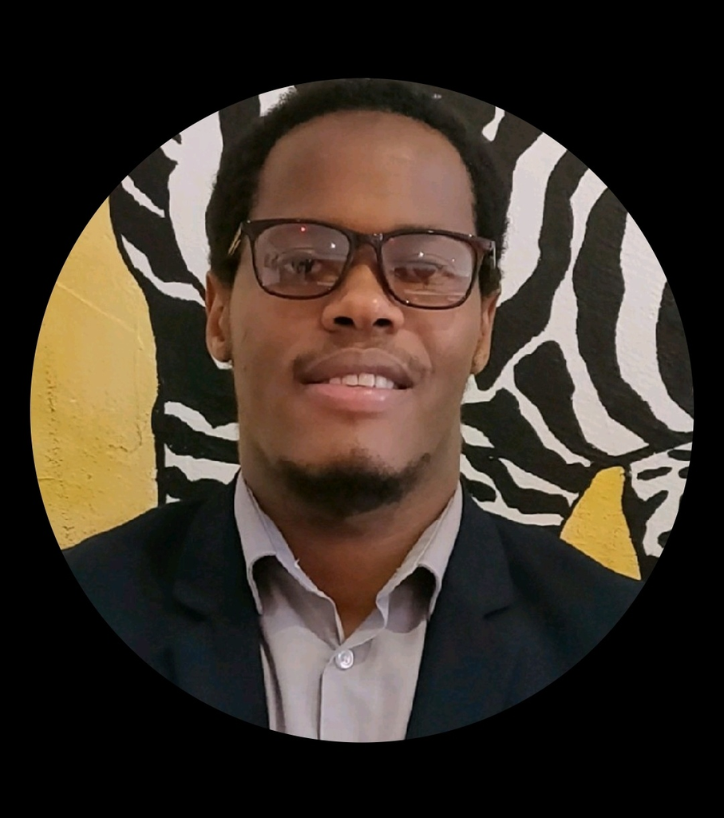

# Kalidou BA

## Bio

Issu d’un double cursus en *Mathématiques appliquées* et en *Intelligence artificielle*, je suis aujourd’hui à la recherche d’une thèse dans ces secteurs-ci. Passionné par les *sciences des données* et par le *numérique*, j’ai pu profiter de mes expériences professionnelles passées pour me spécialiser et acquérir des compétences complémentaires dans le traitement de données massives et dans le développement d’applications informatiques.

## Experience

**INSERM, Université de Bordeaux, Bordeaux** | Méthodes statistiques pour l’analyse différentielle de données RNA-seq en cellule unique appliquées en immunologie.

**Floralis, AGEIS, Université de Grenoble, Grenoble** | Projet de Deep-Covid 2020 | Développement d’application mobile de recensement des bancs dans l’espace public | Développement d’application de traitement de données avec les méthodes de machine learning.

**Orange Labs, Meylan** | Développement de module (Exploitation d’API, machine learning, …) permettant l’enrichissement et l’exploitation d’algorithme d’analyse du comportement humain.

**Mylocalphone, Paris** | Développer des applications Android à destination des hôtels pour leurs clients pour avoir accès à un compte Netflix prépayé, aux informations privilégiées sur l’hôtel, à de nombreuses applications utiles pour visiter la ville. | 2019